# Supplementary File

Open Hospital Prescribing - CDK4/6 Inhibitors

# 1 Treatment Schedules & Licenses

## 1.1 Summary of dosing schedule and Defined Daily Doses (DDD) of CDK4/6 inhibitors

```r
tibble(
  Schedule =
    c("Initial starting dose", "First dose reduction", "Second dose reduction",
      "Days treatment within 28 day cycle", "WHO Defined Daily Dose"),
  Abemaciclib =
    c("150mg Twice Daily", "100mg Twice Daily", "50mg Twice Daily",
      "Continuous", "300mg (2 × 150mg)"),
  Palbociclib =
    c("125mg Once Daily", "100mg Once Daily", "75mg Once Daily",
      "21 days", "94mg (125mg × (21÷28))"),
  Ribociclib =
    c("600mg Once Daily", "400mg Once Daily", "200mg Once Daily",
      "21 days", "450mg (600mg × (21÷28))")
) |> flextable() |>
  set_caption("Summary of dosing schedule and Defined Daily Doses (DDD) of CDK4/6 inhibitors") |>
  flextable::footnote(i=c(1,4), j=c(4,1),
      value=as_paragraph(
        c("Starting dose of ribociclib for adjuvant treatment is 400mg once daily, Ribociclib for adjuvant treatment was not approved during the data period of this study",
          "Daily frequency × individual dose × ( number of days per cycle ÷ cycle length)")),
      ref_symbols = c("a", "b"),
      part = "body") |>
  width(width=4 , unit="cm")|>
  align(j=2:4, align="center", part = "all")
```

Table 1.1: Summary of dosing schedule and Defined Daily Doses (DDD) of CDK4/6 inhibitors

| Schedule | Abemaciclib | Palbociclib | Ribociclib |
| --- | --- | --- | --- |
| Initial starting dose | 150mg Twice Daily | 125mg Once Daily | 600mg Once Dailya |
| First dose reduction | 100mg Twice Daily | 100mg Once Daily | 400mg Once Daily |
| Second dose reduction | 50mg Twice Daily | 75mg Once Daily | 200mg Once Daily |
| Days treatment within 28 day cycleb | Continuous | 21 days | 21 days |
| WHO Defined Daily Dose | 300mg (2 × 150mg) | 94mg (125mg × (21÷28)) | 450mg (600mg × (21÷28)) |

aStarting dose of ribociclib for adjuvant treatment is 400mg once daily, Ribociclib for adjuvant treatment was not approved during the data period of this study  
bDaily frequency × individual dose × ( number of days per cycle ÷ cycle length)

## 1.2 Summary of licensed indication, funding arrangements & licensing studies.

```r
LicTab <- read_csv(here::here("data", "LicensesTable.csv"), show_col_types = FALSE)

LicTab |>
  filter(Detail != "Trial Citation") |>
  as_grouped_data(groups = "Setting") |>
  flextable(theme_fun = "booktabs") |>
  set_caption("Summary of licenses, NICE review and key trial outcomes for CDK4/6 inhibitors") |>
  width(width = c(1.5,2.5,4,4,4), unit="cm")|>
  merge_at(i=1, j=1:3) |>
  hline(i=2, j=2:5)|>
  merge_at(i=3, j=1:3) |>
  hline(i=6, j=2:5)|>
  merge_at(i=9, j=1:3) |>
    hline(i=8, j=2:5)|>
    hline(i=12, j=2:5)|>
  hline(i=14)|>
  merge_at(i=15, j=1:3) |>
    hline(i=16, j=2:5)|>
    hline(i=19, j=2:5)|>
  align(j=3:5, align = "center", part = "all") |>
  bold(j=1:2, bold = T, part ="body") |>
  ftExtra::colformat_md() |>
  footnote(j=c(3,4,5), i=2, value=as_paragraph("In pre- or perimenopausal women, the endocrine therapy should be combined with a LHRH", as_sup("*")," agonist"), part = "body", inline = T, sep ="; ", ref_symbols = "a") |>  # CHECK
  footnote(j="Detail", i=c(5,6,11,12,18,19), value=as_paragraph(as_b("HR"),": Hazard ratio (95% Confidence Interval)"), part = "body", inline = T, sep ="; ", ref_symbols = "b") |>
    footnote(j="Detail", i=c(7,13,20), value=as_paragraph(as_b("CDF"),": Cancer Drugs Fund - provides interim funding immediately following a positive draft NICE technology appraisal"), part = "body", inline = T, sep ="; ", ref_symbols = "c") |>
      footnote(j="Detail", i=c(8,14,21), value=as_paragraph(as_b("TA"),": Technology Appraisal (Date of final guidance)"), part = "body", inline = T, sep =". ", ref_symbols = "d") |>
  footnote(j="Detail", i=c(18,19), value=as_paragraph(as_b("IDFS"),": Invasive Disease Free Survival"), part = "body", inline = T, sep =". ", ref_symbols = "e") |>
  footnote(j="Ribociclib", i=c(16), value=as_paragraph("In pre- or perimenopausal women, or in men, the aromatase inhibitor  should be combined with a LHRH", as_sup("*") , " agonist"), part = "body", inline = T, sep =". ", ref_symbols = "f") |>
    footnote(j=c(3:5,3,5), i=c(2,2,2,16,16), value=as_paragraph(as_b("HR-positive"),": Hormone Receptor positive; ", as_b("HER2"),": Human Epidermal Growth factor Receptor-2; ", as_b("LHRH"),": Luteinizing Hormone‑Releasing Hormone."), part = "body", inline = F, sep =". ", ref_symbols = "*") |>
  footnote(j=3:5, i=2, value=as_paragraph(as_i(as_b("ns")),": not statistically significant by study design"), part = "body", inline = F, sep =".", ref_symbols = " ") |>
    font (fontname = "Arial Narrow", part="all") |>
  fontsize(size=6.5, part = "all") -> ft

ft #|>
```

Table 1.2: Summary of licenses, NICE review and key trial outcomes for CDK4/6 inhibitors

| Setting | Detail | Abemaciclib | Palbociclib | Ribociclib |
| --- | --- | --- | --- | --- |
| Advanced or Metastatic |  |  |  |  |
|  | Licensed indication | Women with HR-positive, HER2-negative locally advanced or metastatic breast cancer in combination with an aromatase inhibitor or fulvestrant as initial endocrine-based therapy, or in women who have re… | Treatment of HR-positive, HER2-negative locally advanced or metastatic breast cancer: in combination with an aromatase inhibitor; or in combination with fulvestrant in women who have received prior en… | Women with HR-positive, HER2-negative locally advanced or metastatic breast cancer in combination with an aromatase inhibitor or fulvestrant as initial endocrine-based therapy, or in women who have re… |
| ‘First Line’ Metastatic |  |  |  |  |
|  | Licensing Trial | MONARCH-31 | PALOMA-23 | MONALEESA-24 |
|  | HR for progressionb | 0.54 (0.42 - 0.70) | 0.54 (0.46 - 0.72) | 0.45 (0.27 - 0.75) |
|  | HR for deathb | 0.76 (0.56-1.03) ns [August 2024]2 | 0.96 (0.77 – 1.18) ns [May 2022] | 0.76 (0.63 - 0.93) [March 2022] |
|  | Date funded by CDFc | 17 January 2019 | 16 November 2017 | 16 November 2017 |
|  | Date of NICE TAd | 27 February 2019 | 20 December 2017 | 20 December 2017 |
| ‘Second Line’ Metastatic |  |  |  |  |
|  | Licensing Trial | MONARCH-2 | PALOMA-3 | MONALEESA-3 |
|  | HR for progressionb | 0.55 (0.45 - 0.69) | 0.46 (0.36–0.59) | 0.72 (0.57 - 0.92) |
|  | HR for deathb | 0.76 (0.61 - 0.95) | 0.81 (0.64 - 1.03) ns | 0.72 (0.57 - 0.92) |
|  | Date funded by CDFc | 02 April 2019 | 28 November 2019 | 26 February 2021 |
|  | Date of NICE TAd | 08 May 2019 | 15 January 2020 | 31 March 2021 |
| Adjuvant |  |  |  |  |
|  | Licensed indication | In combination with endocrine therapy is indicated for the adjuvant treatment of adult patients with HR-positive, HER2-negative, node-positive early breast cancer at high risk of recurrence* |  | In combination with an aromatase inhibitor is indicated for the adjuvant treatment of patients with HR-positive, HER2-negative early breast cancer at high risk of recurrencef* |
|  | Licensing Trial | MONARCH-E | PALLAS | NATALEE |
|  | HR IDFS (3 years)be | 0.68 (0.57 - 0.81) |  | 0.75 (0.62 - 0.91) |
|  | HR IDFS (5 years)be | 0.68 (0.60 - 0.77) | 0.96 (0.81 - 1.14) ns [4 years] |  |
|  | Date funded by CDFc | 17 June 2022 |  | 24 April 2025 (Node positive cohort), 23 July 2025 (Whole cohort) |
|  | Date of NICE TAd | 20 July 2022 |  | 06 August 2025 |

aIn pre- or perimenopausal women, the endocrine therapy should be combined with a LHRH* agonist; bHR: Hazard ratio (95% Confidence Interval); cCDF: Cancer Drugs Fund - provides interim funding immediately following a positive draft NICE technology appraisal; dTA: Technology Appraisal (Date of final guidance). eIDFS: Invasive Disease Free Survival. fIn pre- or perimenopausal women, or in men, the aromatase inhibitor should be combined with a LHRH* agonist.  
*HR-positive: Hormone Receptor positive; HER2: Human Epidermal Growth factor Receptor-2; LHRH: Luteinizing Hormone-Releasing Hormone.  
ns: not statistically significant by study design

```r
  #  ftExtra::colformat_md()

## Big chunk of code here to find ns and apply bold italics to it.
#
# ft$body$dataset$Abemaciclib |> str_detect(" ns ") ->ab
# ft$body$dataset$Palbociclib |> str_detect(" ns ") ->pb
# ft$body$dataset$Ribociclib |> str_detect(" ns ") ->rb
#
# for (i in 1:length(ab)) {
#   if(!is.na(ab[i])) {
#     if (ab[i] == T ) {
#       str <- stringr::str_split_1(ft$body$dataset$Abemaciclib[i], " ns ")
#       if (length(str) >1 ) {
#         new_str <- as_paragraph(str[1], as_i(as_b(" ns ")), str[2])
#       } else {
#         new_str <- as_paragraph(str[1], as_i(as_b(" ns ")))
#       }
#
#       mk_par(ft, i=i, j=3, new_str) -> ft
#
#     }
#   }
# }
#
# for (i in 1:length(pb)) {
#   if(!is.na(pb[i])) {
#     if (pb[i] == T ) {
#       str <- stringr::str_split_1(ft$body$dataset$Palbociclib[i], " ns ")
#       if (length(str) >1 ) {
#         new_str <- as_paragraph(str[1], as_i(as_b(" ns ")), str[2])
#       } else {
#         new_str <- as_paragraph(str[1], as_i(as_b(" ns ")))
#       }
#
#       mk_par(ft, i=i, j=4, new_str) -> ft
#
#     }
#   }
# }
#
# for (i in 1:length(rb)) {
#   if(!is.na(rb[i])) {
#     if (rb[i] == T ) {
#       str <- stringr::str_split_1(ft$body$dataset$Ribociclib[i], " ns ")
#       if (length(str) >1 ) {
#         new_str <- as_paragraph(str[1], as_i(as_b(" ns ")), str[2])
#       } else {
#         new_str <- as_paragraph(str[1], as_i(as_b(" ns ")))
#       }
#
#       mk_par(ft, i=i, j=5, new_str) -> ft
#
#     }
#   }
# }
#
# ft
```

# 2 Dispensing of Treatments

## 2.1 Summary of number of tablets or capsules of different formulations issued by calendar year.

```r
# Get the dataset
# Requires cleaned data
cdk46Data <- readRDS(here::here("data/cdk46_op_hosp_clean.RDS"))

cdk46Data|>
  mutate(year = year(year_month))|>
  rowwise()|>
  mutate(vtm = stringr::str_split_1(as.character(vmp_name), " ")[1]) |>
  mutate(vmp_short_name = paste(stringr::str_split_1(as.character(vmp_name), " ")[2:3], collapse=" ")) |>
  filter(year < 2025)|>
  group_by(vtm, vmp_short_name, vmp_code, year) |>
  summarise(quantity = sum(quantity)) |>
  pivot_wider(names_from = year, values_from = quantity) |>
  mutate(vmp = paste0(vmp_short_name, " (", vmp_code, ")"), .after = vtm) |>
  ungroup()|>
  select(-vmp_short_name, -vmp_code) |>
  as_grouped_data( groups = c("vtm"), columns = NULL) %>%
  flextable() |>
  set_caption("Summary of number of tablets or capsules of different formulations issued by calendar year.") |>
   flextable::footnote(i=c(6,8,10), j=c(2,2,2),
      value=as_paragraph(
        c("Palbociclib capsules were phased out in January 2021")),
      ref_symbols = c("a"),
      part = "body") |>
      colformat_double(digits = 0) |>
      font (fontname = "Arial Narrow", part="all") |>
      fontsize(size=10, part = "all")|>
      # dim_pretty(unit="cm")
      width(width=c(1, 5.5, 1.65, 1.65, 1.65, 1.65, 1.65, 1.65) , unit="cm")|>
      add_header_row(values=c("Virtual Medicinal Product", "Calendar Year"), colwidths = c(2, 6))
```

Table 2.1: Summary of number of tablets or capsules of different formulations issued by calendar year.

| Virtual Medicinal Product vtm | Virtual Medicinal Product vmp | Calendar Year 2019 | Calendar Year 2020 | Calendar Year 2021 | Calendar Year 2022 | Calendar Year 2023 | Calendar Year 2024 |
| --- | --- | --- | --- | --- | --- | --- | --- |
| Abemaciclib |  |  |  |  |  |  |  |
|  | 100mg tablets (36237011000001104) | 85,050 | 221,440 | 251,748 | 325,140 | 890,601 | 1,668,758 |
|  | 150mg tablets (36237111000001104) | 196,174 | 279,195 | 278,650 | 445,543 | 1,085,718 | 1,455,247 |
|  | 50mg tablets (36237211000001112) | 40,336 | 94,690 | 106,044 | 142,143 | 339,790 | 843,583 |
| Palbociclib |  |  |  |  |  |  |  |
|  | 100mg capsules (33734111000001108)a | 192,917 | 278,657 | 48,197 | 11,490 | 7,036 | 6,650 |
|  | 100mg tablets (39343711000001104) | 987 | 3,990 | 345,551 | 425,798 | 420,349 | 402,246 |
|  | 125mg capsules (33734211000001100)a | 445,014 | 528,179 | 76,095 | 12,153 | 6,960 | 3,741 |
|  | 125mg tablets (39343811000001104) |  | 2,709 | 594,285 | 683,102 | 578,510 | 504,669 |
|  | 75mg capsules (33734311000001108)a | 101,387 | 163,171 | 28,327 | 6,093 | 4,753 | 5,278 |
|  | 75mg tablets (39343911000001104) |  | 21 | 200,504 | 288,658 | 323,588 | 347,644 |
| Ribociclib |  |  |  |  |  |  |  |
|  | 200mg tablets (34814111000001104) | 239,007 | 375,835 | 389,107 | 548,535 | 976,565 | 1,450,469 |

aPalbociclib capsules were phased out in January 2021

## 2.2 Summary of Defined Daily Doses by VMP

```r
cdk46Data|>
  mutate(year = year(year_month))|>
  rowwise()|>
  mutate(vtm = stringr::str_split_1(as.character(vmp_name), " ")[1]) |>
  mutate(vmp_short_name = paste(stringr::str_split_1(as.character(vmp_name), " ")[2:3], collapse=" ")) |>
  filter(year < 2025)|>
  group_by(vtm, year) |>
  summarise(quantity = sum(ddd_quantity)) |>
  pivot_wider(names_from = year, values_from = quantity) |>
  ungroup()|>
  as_grouped_data( groups = c("vtm"), columns = NULL) %>%
  flextable() |>
  set_caption("Summary of number of defined daily doses issued by calendar year.") |>
      colformat_double(digits = 0) |>
      font (fontname = "Arial Narrow", part="all") |>
      fontsize(size=10, part = "all") #|>
```

Table 2.2: Summary of number of defined daily doses issued by calendar year.

| vtm | 2019 | 2020 | 2021 | 2022 | 2023 | 2024 |
| --- | --- | --- | --- | --- | --- | --- |
| Abemaciclib |  |  |  |  |  |  |
|  | 133,160 | 229,193 | 240,915 | 354,842 | 896,358 | 1,424,473 |
| Palbociclib |  |  |  |  |  |  |
|  | 878,949 | 1,136,863 | 1,492,922 | 1,624,915 | 1,495,190 | 1,392,659 |
| Ribociclib |  |  |  |  |  |  |
|  | 106,225 | 167,038 | 172,936 | 243,793 | 434,029 | 644,653 |

## 2.3 NHS Trusts and Cancer Alliances.

```r
cdk46Data |>
  filter(year_month < as.Date("2025-01-01"))|>
  group_by(`Cancer Alliance` = as.character(Alliance_name), `NHS Trust` = as.character(Trust_name)) |>
  summarise(`No of CDK4/6 tablets/capsules dispensed` = sum(quantity)) |>
  ungroup()|>
 as_grouped_data( groups = c("Cancer Alliance"), columns = NULL) |>
  flextable() |>
       colformat_double(digits = 0) |>
      font (fontname = "Arial Narrow", part="all") |>
      fontsize(size=10, part = "all")|>
      # dim_pretty(unit="cm")
      width(width=c(5,8, 3) , unit="cm") |>
    set_caption("List of NHS Trusts, by Cancer Alliance and total number of tablets or capsules of any CDK 4/6 inhibitor dispensed between 2019 and 2024.")
```

Table 2.3: List of NHS Trusts, by Cancer Alliance and total number of tablets or capsules of any CDK 4/6 inhibitor dispensed between 2019 and 2024.

| Cancer Alliance | NHS Trust | No of CDK4/6 tablets/capsules dispensed |
| --- | --- | --- |
| CHESHIRE AND MERSEYSIDE CANCER ALLIANCE |  |  |
|  | EAST CHESHIRE NHS TRUST | 4,916 |
|  | LIVERPOOL UNIVERSITY HOSPITALS NHS FOUNDATION TRUST | 2,345 |
|  | MID CHESHIRE HOSPITALS NHS FOUNDATION TRUST | 17,003 |
|  | THE CLATTERBRIDGE CANCER CENTRE NHS FOUNDATION TRUST | 813,312 |
| EAST MIDLANDS CANCER ALLIANCE |  |  |
|  | CHESTERFIELD ROYAL HOSPITAL NHS FOUNDATION TRUST | 763 |
|  | KETTERING GENERAL HOSPITAL NHS FOUNDATION TRUST | 99,589 |
|  | NORTHAMPTON GENERAL HOSPITAL NHS TRUST | 96,954 |
|  | NOTTINGHAM UNIVERSITY HOSPITALS NHS TRUST | 586,754 |
|  | UNITED LINCOLNSHIRE TEACHING HOSPITALS NHS TRUST | 214,479 |
|  | UNIVERSITY HOSPITALS OF DERBY AND BURTON NHS FOUNDATION TRUST | 236,943 |
|  | UNIVERSITY HOSPITALS OF LEICESTER NHS TRUST | 277,760 |
| EAST OF ENGLAND - NORTH CANCER ALLIANCE |  |  |
|  | CAMBRIDGE UNIVERSITY HOSPITALS NHS FOUNDATION TRUST | 125,018 |
|  | EAST SUFFOLK AND NORTH ESSEX NHS FOUNDATION TRUST | 451,275 |
|  | JAMES PAGET UNIVERSITY HOSPITALS NHS FOUNDATION TRUST | 37,101 |
|  | NORFOLK AND NORWICH UNIVERSITY HOSPITALS NHS FOUNDATION TRUST | 137,772 |
|  | NORTH WEST ANGLIA NHS FOUNDATION TRUST | 170,240 |
|  | THE QUEEN ELIZABETH HOSPITAL, KING'S LYNN, NHS FOUNDATION TRUST | 70,812 |
|  | WEST SUFFOLK NHS FOUNDATION TRUST | 63,387 |
| EAST OF ENGLAND - SOUTH CANCER ALLIANCE |  |  |
|  | BEDFORDSHIRE HOSPITALS NHS FOUNDATION TRUST | 168,525 |
|  | EAST AND NORTH HERTFORDSHIRE NHS TRUST | 344,983 |
|  | MID AND SOUTH ESSEX NHS FOUNDATION TRUST | 346,771 |
|  | MILTON KEYNES UNIVERSITY HOSPITAL NHS FOUNDATION TRUST | 147,419 |
|  | THE PRINCESS ALEXANDRA HOSPITAL NHS TRUST | 113,127 |
| GREATER MANCHESTER CANCER ALLIANCE |  |  |
|  | BOLTON NHS FOUNDATION TRUST | 16,744 |
|  | STOCKPORT NHS FOUNDATION TRUST | 30,184 |

[output cut: 103 more lines]

# 3 Dose Reductions

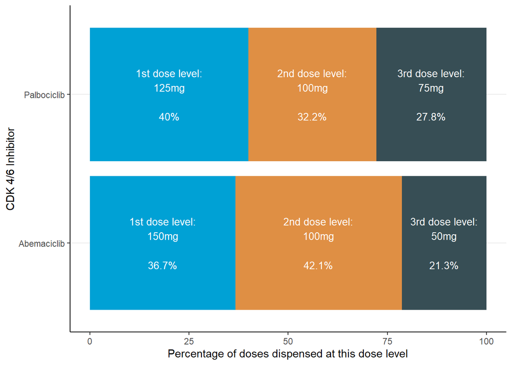

Figure 3.1: Distribution of doses for palbocilib and abemaciclib dispensed in 2024

```r
cdk46Data|>
  mutate(year = year(year_month))|>
  rowwise()|>
  mutate(vtm = stringr::str_split_1(as.character(vmp_name), " ")[1]) |>
  mutate(strength = stringr::str_split_1(as.character(vmp_name), " ")[2]) |>
  mutate(strength_mg = as.numeric(stringr::str_remove(strength, "mg") )) |>
  filter(vtm != "Ribociclib") |>
  filter(year == 2024) |>
  group_by(vtm, strength_mg) |>
  summarise(quantity = sum(quantity)) |>
  mutate(Dose_level = toOrdinal::toOrdinal(rank(-strength_mg))) |>
  mutate(percentage = 100*(quantity/sum(quantity))) -> doseSummary

doseSummary |>
  mutate(Dose_level = as.factor(Dose_level)) |>
  arrange(Dose_level) |>
  mutate(label = glue::glue(
    "{Dose_level} dose level:\n{strength_mg}mg\n\n{round(percentage,1)}%")) |>
  mutate(cum_percentage = cumsum(percentage) ) |>
  mutate(label_pos = cumsum(percentage) - (percentage/2)) |>
  ggplot(aes(x=vtm, y=percentage, fill=forcats::fct_rev(Dose_level))) +
  geom_col() +
  theme_bw() +
  ggsci::scale_fill_jama() +
  theme(panel.grid.minor = element_blank(),
        panel.grid.major.x = element_blank()) +
  theme(panel.border = element_blank(),
        axis.line = element_line(linewidth = 0.5, colour = "black") ,
        legend.position = "none") +
  ylab("Percentage of doses dispensed at this dose level") +
  xlab("CDK 4/6 Inhibitor") +
    coord_flip()+
  geom_text(aes(label=label, y= label_pos), size=3.5, color="white")
```

Dose modifications for CDK4/6 inhibitors are common. Ribociclib is supplied as 200mg tablets and therefore it is not possible to determine from aggregate issuing data how frequently a dose modification may occur. Different strength tablets are used to supply dose modifications for palbociclib and abemaciclib. Using the data from 2024, the proportion of different tablet strengths is shown in Figure 3.1

63.3% of patients on abemaciclib are on a reduced dose, in contrast to the MorachE trial which only had 43.7% dose reductions overall and just 13.9% on the lowest dose.

60% of patients on palbociclib were also dose reduced.

# 4 Change in Prescribing

The ratio of palbociclib to ribociclib prescribed by Cancer Alliance changed for every Alliance when comparing July-Decemeber 2021 to January-June 2024. The change for each Alliance is tabulated below:

```r
# This is calculated in the Map_plots.Rmd and simply imported here

change_table <- readRDS(here::here("r/r-notebook/change_table.RDS"))

change_table
```

| Cancer_Alliance | 2021 | 2024 | change |
| --- | --- | --- | --- |
| Cheshire and Merseyside Cancer Alliance | 42.67 | 4.87 | −88.6% |
| East Midlands Cancer Alliance | 5.70 | 2.97 | −47.8% |
| East of England - North Cancer Alliance | 3.54 | 1.59 | −55.0% |
| East of England - South Cancer Alliance | 7.87 | 2.35 | −70.1% |
| Greater Manchester Cancer Alliance | 11.70 | 1.69 | −85.5% |
| Humber and North Yorkshire Cancer Alliance | 4.28 | 2.53 | −40.9% |
| Kent and Medway Cancer Alliance | 35.36 | 3.71 | −89.5% |
| Lancashire and South Cumbria Cancer Alliance | 18.52 | 4.95 | −73.3% |
| North Central London Cancer Alliance | 10.87 | 1.40 | −87.1% |
| North East London Cancer Alliance | 66.71 | 3.50 | −94.8% |
| Northern Cancer Alliance | 34.96 | 1.86 | −94.7% |
| Peninsula Cancer Alliance | 5.25 | 1.15 | −78.2% |
| Somerset, Wiltshire, Avon and Gloucestershire Cancer Alliance | 29.62 | 4.10 | −86.2% |
| South East London Cancer Alliance | 3.32 | 0.90 | −72.8% |
| South Yorkshire and Bassetlaw Cancer Alliance | 14.70 | 2.10 | −85.7% |
| Surrey and Sussex Cancer Alliance | 5.75 | 1.38 | −75.9% |
| Thames Valley Cancer Alliance | 4.60 | 1.62 | −64.9% |
| Wessex Cancer Alliance | 7.22 | 2.78 | −61.6% |
| West London Cancer Alliance | 8.08 | 2.06 | −74.5% |
| West Midlands Cancer Alliance | 11.34 | 3.09 | −72.8% |
| West Yorkshire and Harrogate Cancer Alliance | 7.02 | 3.72 | −47.0% |

# 5 R Packages

```r
cite_packages(output="paragraph", out.dir =here::here("r/r-notebook")) #|>
```

We used R version 4.1.3<sup>5</sup> and the following R packages: bookdown v. 0.31<sup>6,7</sup>, devtools v. 2.4.5<sup>8</sup>, directlabels v. 2025.6.24<sup>9</sup>, flextable v. 0.9.10<sup>10</sup>, ftExtra v. 0.6.4.9999<sup>11</sup>, ggsci v. 3.2.0<sup>12</sup>, glue v. 1.8.0<sup>13</sup>, gridExtra v. 2.3<sup>14</sup>, gt v. 1.0.0<sup>15</sup>, gtsummary v. 1.5.2<sup>16</sup>, here v. 1.0.1<sup>17</sup>, kableExtra v. 1.3.4<sup>18</sup>, knitr v. 1.50<sup>19–21</sup>, NHSRtools v. 0.0.0.9001<sup>22</sup>, rmarkdown v. 2.29<sup>23–25</sup>, scales v. 1.4.0<sup>26</sup>, sf v. 1.0.9<sup>27</sup>, tidyverse v. 2.0.0<sup>28</sup>, toOrdinal v. 1.3.0.0<sup>29</sup>, zoo v. 1.8.9<sup>30</sup>.

```r
  # flextable() |>
  # ftExtra::colformat_md()
```

```r
#nocite_references(cite_packages(output="citekeys", out.dir =here::here("r/r-notebook")))
```

# 6 Supplemental References

These references may have also been cited in the main body of the text.

1.

Goetz MP, Toi M, Campone M, et al. MONARCH 3: Abemaciclib As Initial Therapy for Advanced Breast Cancer. *JCO*. 2017;35(32):3638-3646. doi:10.1200/jco.2017.75.6155

2.

Goetz MP, Toi M, Huober J, et al. Abemaciclib plus a nonsteroidal aromatase inhibitor as initial therapy for HR+, HER2− advanced breast cancer: final overall survival results of MONARCH 3. *Annals of Oncology*. 2024;35(8):718-727. doi:10.1016/j.annonc.2024.04.013

3.

Finn RS, Martin M, Rugo HS, et al. Palbociclib and Letrozole in Advanced Breast Cancer. *N Engl J Med*. 2016;375(20):1925-1936. doi:10.1056/nejmoa1607303

4.

Hortobagyi GN, Stemmer SM, Burris HA, et al. Ribociclib as First-Line Therapy for HR-Positive, Advanced Breast Cancer. *N Engl J Med*. 2016;375(18):1738-1748. doi:10.1056/nejmoa1609709

5.

R Core Team. *R: A Language and Environment for Statistical Computing*. R Foundation for Statistical Computing; 2022. https://www.R-project.org/

6.

Xie Y. *bookdown: Authoring Books and Technical Documents with R Markdown*. Chapman; Hall/CRC; 2016. https://bookdown.org/yihui/bookdown

7.

Xie Y. *bookdown: Authoring Books and Technical Documents with r Markdown*.; 2022. https://github.com/rstudio/bookdown

8.

Wickham H, Hester J, Chang W, Bryan J. *devtools: Tools to Make Developing r Packages Easier*.; 2022. https://CRAN.R-project.org/package=devtools

9.

Hocking TD. *directlabels: Direct Labels for Multicolor Plots*.; 2025. https://CRAN.R-project.org/package=directlabels

10.

Gohel D, Skintzos P. *flextable: Functions for Tabular Reporting*.; 2025. https://CRAN.R-project.org/package=flextable

11.

Yasumoto A. *ftExtra: Extensions for “Flextable”*.; 2024.

12.

Xiao N. *ggsci: Scientific Journal and Sci-Fi Themed Color Palettes for “ggplot2”*.; 2024. https://CRAN.R-project.org/package=ggsci

13.

Hester J, Bryan J. *glue: Interpreted String Literals*.; 2024. https://CRAN.R-project.org/package=glue

14.

Auguie B. *gridExtra: Miscellaneous Functions for “Grid” Graphics*.; 2017. https://CRAN.R-project.org/package=gridExtra

15.

Iannone R, Cheng J, Schloerke B, et al. *gt: Easily Create Presentation-Ready Display Tables*.; 2025. https://CRAN.R-project.org/package=gt

16.

Sjoberg DD, Whiting K, Curry M, Lavery JA, Larmarange J. Reproducible summary tables with the gtsummary package. *The R Journal*. 2021;13:570-580. doi:10.32614/RJ-2021-053

17.

Müller K. *here: A Simpler Way to Find Your Files*.; 2020. https://CRAN.R-project.org/package=here

18.

Zhu H. *kableExtra: Construct Complex Table with “kable” and Pipe Syntax*.; 2021. https://CRAN.R-project.org/package=kableExtra

19.

Xie Y. knitr: A comprehensive tool for reproducible research in R. In: Stodden V, Leisch F, Peng RD, eds. *Implementing Reproducible Computational Research*. Chapman; Hall/CRC; 2014.

20.

Xie Y. *Dynamic Documents with R and Knitr*. 2nd ed. Chapman; Hall/CRC; 2015. https://yihui.org/knitr/

21.

Xie Y. *knitr: A General-Purpose Package for Dynamic Report Generation in R*.; 2025. https://yihui.org/knitr/

22.

Jemmett T. *NHSRtools: NHS-r Tools*.; 2025.

23.

Xie Y, Allaire JJ, Grolemund G. *R Markdown: The Definitive Guide*. Chapman; Hall/CRC; 2018. https://bookdown.org/yihui/rmarkdown

24.

Xie Y, Dervieux C, Riederer E. *R Markdown Cookbook*. Chapman; Hall/CRC; 2020. https://bookdown.org/yihui/rmarkdown-cookbook

25.

Allaire J, Xie Y, Dervieux C, et al. *rmarkdown: Dynamic Documents for r*.; 2024. https://github.com/rstudio/rmarkdown

26.

Wickham H, Pedersen TL, Seidel D. *scales: Scale Functions for Visualization*.; 2025. https://CRAN.R-project.org/package=scales

27.

Pebesma E. Simple Features for R: Standardized Support for Spatial Vector Data. *The R Journal*. 2018;10(1):439-446. doi:10.32614/RJ-2018-009

28.

Wickham H, Averick M, Bryan J, et al. Welcome to the tidyverse. *Journal of Open Source Software*. 2019;4(43):1686. doi:10.21105/joss.01686

29.

Betebenner DW. *toOrdinal: Function for Converting Cardinal to Ordinal Numbers by Adding a Language Specific Ordinal Indicator to the Number*.; 2022. https://centerforassessment.github.io/toOrdinal/

30.

Zeileis A, Grothendieck G. zoo: S3 infrastructure for regular and irregular time series. *Journal of Statistical Software*. 2005;14(6):1-27. doi:10.18637/jss.v014.i06